# Photoreactivation, a self-repairing system in Saccharomyces cerevisiae (EDA Assignment 01)

Wang YueDuo sdu202000700268

2022-04-23

## Our research question is: whether can we observe photoreactive repair process in yeast cells?

# Part 1: Explore the best dilution and UV-C exposure time:

In this section, we are going to explore the best dilution of yeast culture and UV-C exposure time as the experiment condition in next section.

First, read the data file of kill curve, to get the relationship between UV-C exposure time and amount of killed yeast cells:

```r
k.c <- read.csv("yeast_uv_kill_curve.csv", stringsAsFactors = T)
View(k.c)
```

Draw box plot to see the range and mean of yeast cells in each yeast culture plates from both 1/10 and 1/100 dilution group.

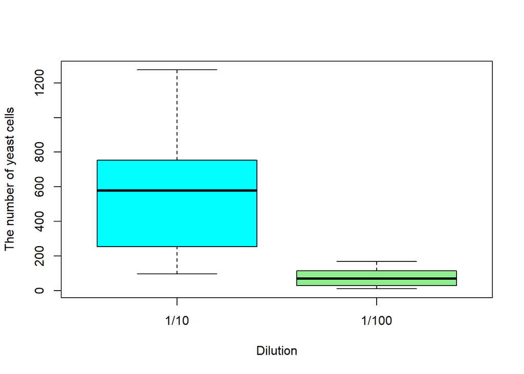

```r
boxplot(cell_count ~ dilution, data = k.c, col = c("cyan","lightgreen"), xlab="Dilution", ylab="The number of yeast cells")
```

To get more information, scatter plot is necessary.

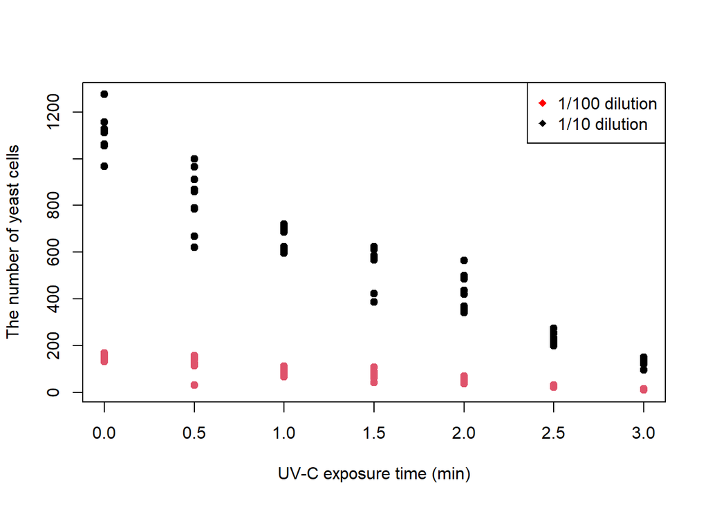

```r
plot(cell_count ~ exposure_time, data = k.c, pch = 20, cex = 1.5, col = dilution, xlab=("UV-C exposure time (min)"),ylab=("The number of yeast cells"))

#Add a legend:
legend("topright",
    legend=c("1/100 dilution","1/10 dilution"),
    col=c("red","black"),
    pch=c(18,18))
```

From the scatter plot, we can obverse that if we choose 1/10, then hundreds, even thousands of colonies in each plate are going to be counted. Obviously, this undoubtedly increases the workload. Like the box plots, 1/100 dilution is much easier for counting colonies. Thus, the best dilution were determined to 1/100.

Then, best UV-C exposure time should be determined. Considering that only 1/100 dilution is needed, we use subset, and plot it.

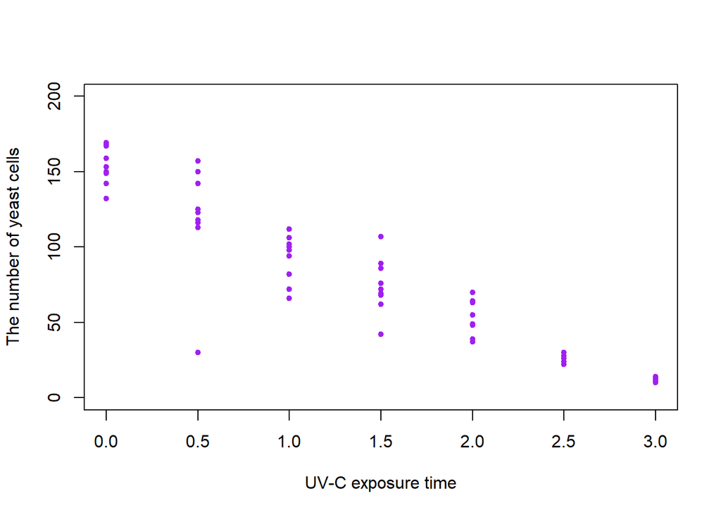

```r
k.c.100 <- subset(k.c, dilution == "1/100")
plot(cell_count ~ exposure_time, data = k.c.100, pch = 20, col = "purple", ylim= c(0, 200),xlab="UV-C exposure time", ylab="The number of yeast cells")
```

It should be noticed that at 3min, almost all the cells were killed. Thus, we need to find a UV-C exposure time point that just half of the yeast cells were killed as the best UV-C exposure time. This time point is named as “UV-C LD50”.

To solve this problem, we use linear regression to fitting a regression line to get more information.

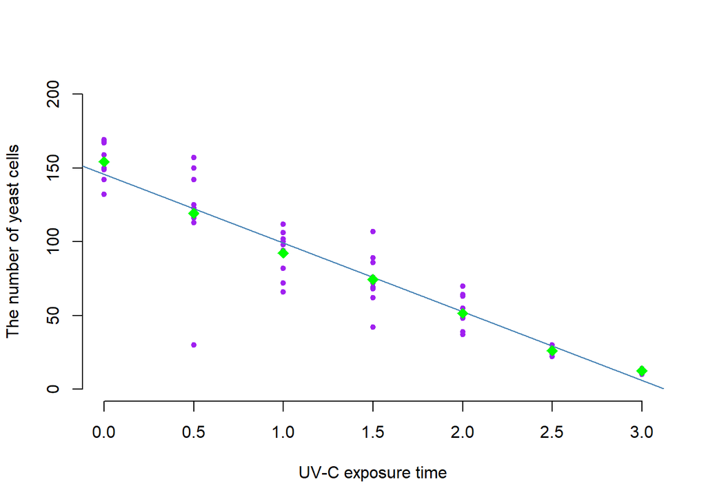

```r
k.c.100.lm <- lm(cell_count ~ exposure_time, data = k.c.100)

plot(cell_count ~ exposure_time, data = k.c.100, pch = 20, col = "purple", bty = "n", xlim= c(0, 3), ylim= c(0, 200),xlab="UV-C exposure time", ylab="The number of yeast cells")
abline(k.c.100.lm, col = "steelblue", lwd = 1)


#Add the mean into this plot:
k.c.100.mean <- aggregate(cell_count ~ exposure_time, data = k.c.100, mean)
points(k.c.100.mean,pch = 18, col = "green", cex = 1.5)
```

Let UV-C exposure time to be the Y-axis, which is more convenient for counting UV-C LD50.

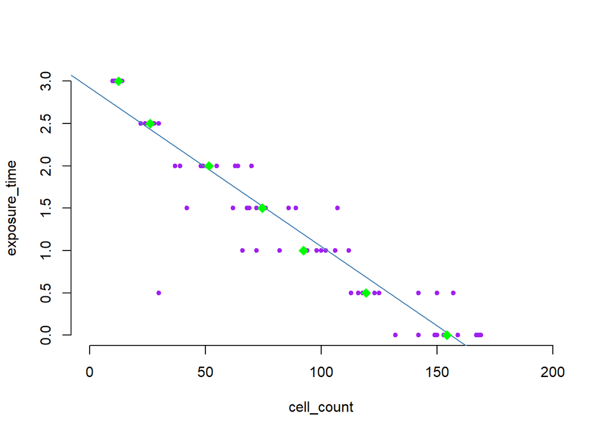

```r
k.c.100.lm <- lm(exposure_time ~ cell_count, data = k.c.100)

plot(exposure_time ~ cell_count, data = k.c.100, pch = 20, col = "purple", bty = "n", ylim = c(0, 3), xlim = c(0, 200))
abline(k.c.100.lm, col = "steelblue", lwd = 1)
points(k.c.100.mean$cell_count, k.c.100.mean$exposure_time, pch = 18, col = "green", cex = 1.5)
```

Now calculate UV-C LD50:

```r
#Get the middle value of the number of yeast cells: (max+min)/2
k.c.100.mid <- (max(k.c.100.mean) + min(k.c.100.mean)) / 2

LD50 <- predict(k.c.100.lm, data.frame(cell_count = k.c.100.mid))
paste("UV-C LD50 exposure time is:", round(LD50, 1))
```

```
## [1] "UV-C LD50 exposure time is: 1.5"
```

Thus, the UV-C LD50 is: 1.5min. ### Now we have determined best dilution (1/100) and UV-C exposure time (1.5min).

# Part 2: Statistical Analysis:

In this section, we are going to analysis the datas and get our conclusion.

```r
# Notice that all the values and data in previous section are NOT going to be used in this part, so it would be better to remove them , to avoid interference.
rm(list=ls())
y.i <- read.csv("yeast_uv_irradiation.csv", stringsAsFactors = T)
```

It should be noticed that if some wrong data were accidentally collected, they may causing large error to the analysis. Thus, before we using One-Way ANOVA to analysing the data, it must be checked firstly.

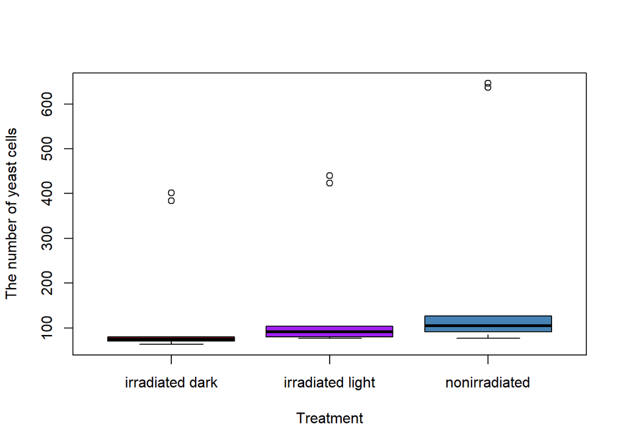

```r
# Just as what we did in previous section, using a box plot to preview the data.
boxplot(cell_count ~ treatment, data = y.i, xlab=("Treatment"), ylab=("The number of yeast cells"), col= c("brown","purple","steelblue"))
```

It can be clearly obversed that each group does have 2 outlier points. If this checking procedure were skipped, then we are going to get a wrong conclusion in a large probability. Since we have found that there are some outlier points, it would be better to check it more specificly.

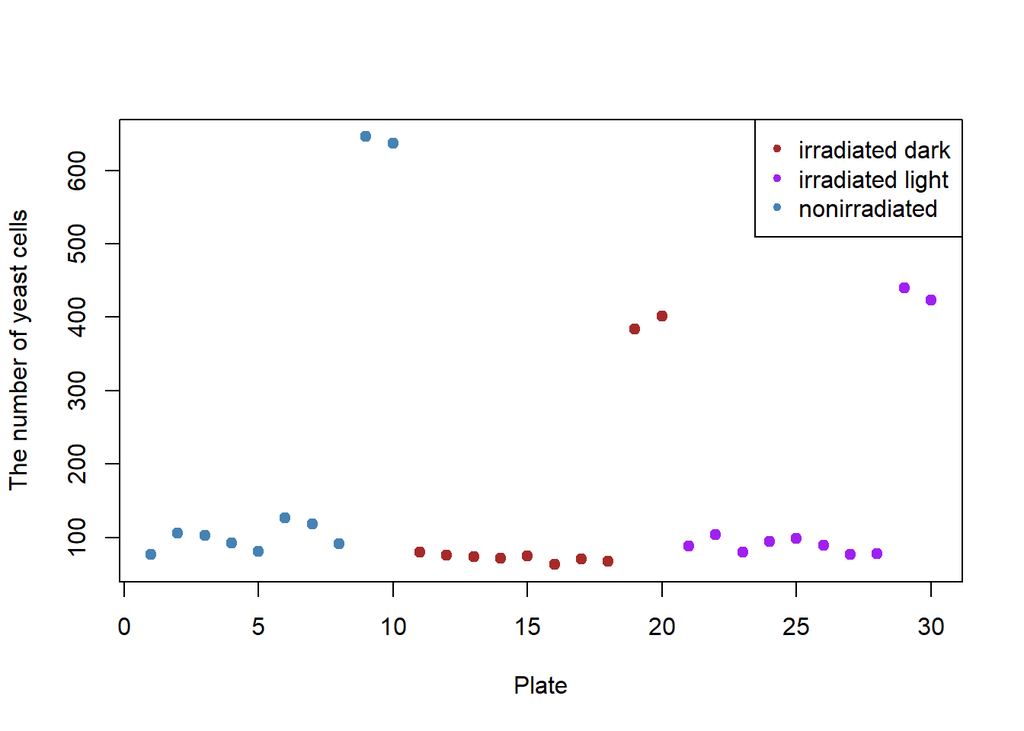

```r
palette(c("brown","purple","steelblue"))
plot(cell_count ~ plate, data = y.i, col = treatment, pch = 20, cex = 1.5,xlab=("Plate"),ylab=("The number of yeast cells"))
legend("topright", levels(y.i$treatment), pch = 20, col = 1:nlevels(y.i$treatment))
```

There do exist some outlier points, which must be removed before we do next analysis procedure.

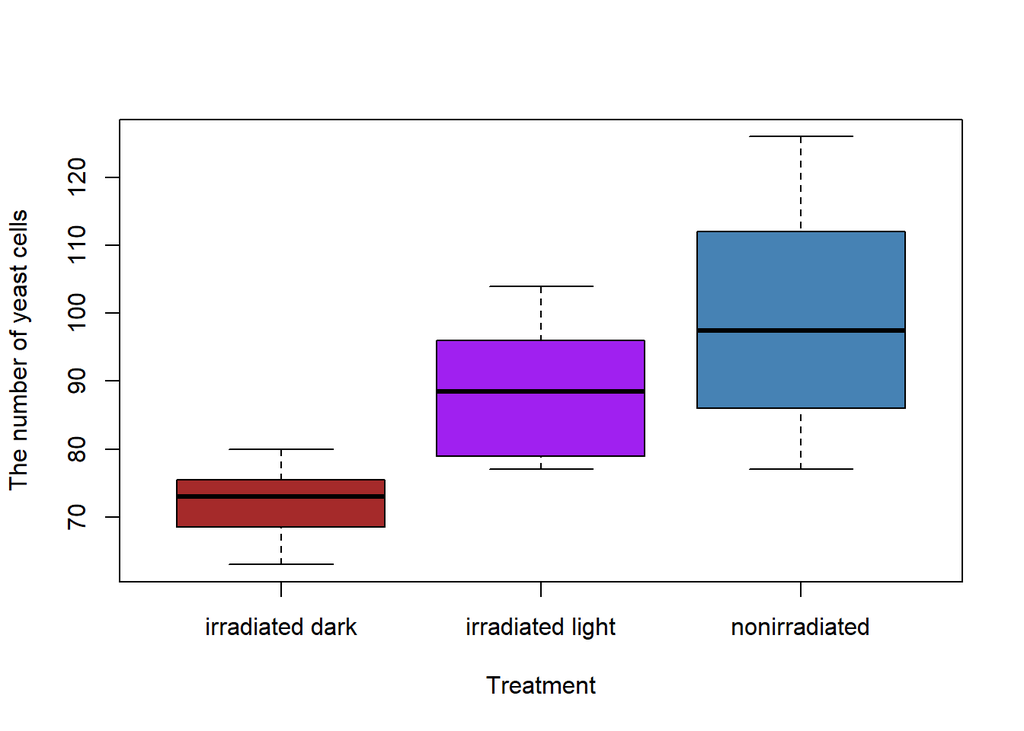

```r
y.f <- subset(y.i, cell_count < 250)
boxplot(cell_count ~ treatment, data = y.f, col= c("brown","purple","steelblue"),xlab=("Treatment"), ylab=("The number of yeast cells"))
```

Now it does look better, using one-way ANOVA to analysis.

```r
y.f.a <- aov(cell_count ~ treatment, data = y.f)
summary(y.f.a)
```

```
##             Df Sum Sq Mean Sq F value   Pr(>F)
## treatment    2   2985  1492.6   10.61 0.000654 ***
## Residuals   21   2954   140.7
## ---
## Signif. codes:  0 '***' 0.001 '**' 0.01 '*' 0.05 '.' 0.1 ' ' 1
```

P-value is much less than 0.05, then perform TukeyHSD test to see exactly the relationship between which two groups are statistically significant.

```r
TukeyHSD(y.f.a)
```

```
##   Tukey multiple comparisons of means
##     95% family-wise confidence level
##
## Fit: aov(formula = cell_count ~ treatment, data = y.f)
##
## $treatment
##                                    diff       lwr      upr     p adj
## irradiated light-irradiated dark 16.375  1.426694 31.32331 0.0301853
## nonirradiated-irradiated dark    27.125 12.176694 42.07331 0.0004652
## nonirradiated-irradiated light   10.750 -4.198306 25.69831 0.1898423
```

Plot TukeyHSD analysis result.

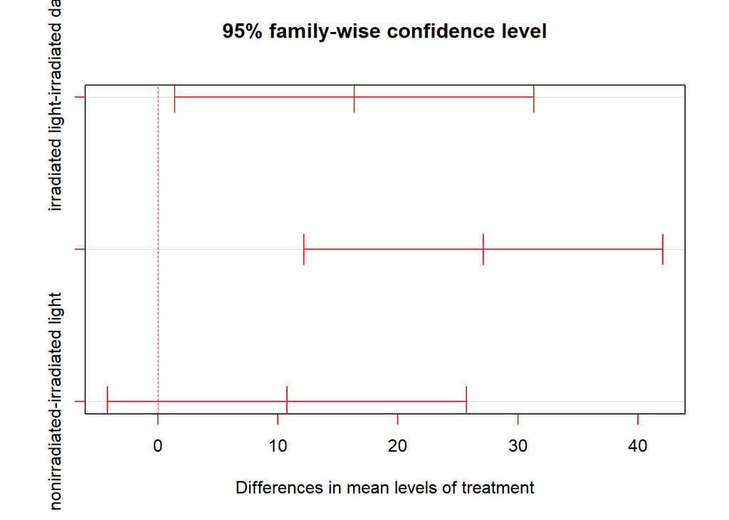

```r
plot(TukeyHSD(y.f.a), col = "red")
```

From TukeyHSD test, we obtained the p-value of “irradiated light-irradiated dark” group (P=0.0301853) and “nonirradiated-irradiated dark” group (P=0.0004652) are less than 0.05, which means they are statistically significant.

From the tukeyHSD test and plot, we also obtained the 95% family-wise confidence level.

```r
Mean <- aggregate(cell_count ~ treatment, data = y.f, mean)
View(Mean)
```

Using diagnostic plots to check ANOVA assumption:

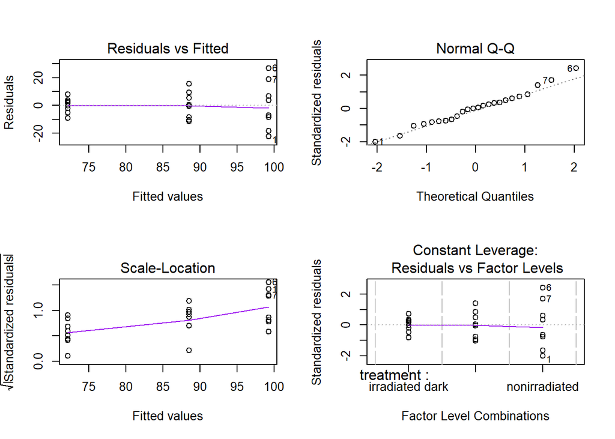

```r
par(mfrow = c(2, 2))
plot(y.f.a)
```

```r
par(mfrow = c(1, 1))
```

### Conclusion:

PR process do exist and was obversed in UV-C treated yeast cell, after being exposured under sunlight. “nonirradiated-irradiated dark” group (P=0.0004652) shown us that UV-C exposure for 1/100 dilution and 1.5min did kill a certain amount of yeast cells. “irradiated light-irradiated dark” group (P=0.0301853) shown us that exposuring under sunlight after UV-C exposure treatment did increase the survival amount of yeast cells, which implies that photoreactive repair process do exist in yeast cells, and it worked and was observed exposuring under sunlight after UV-C treatment.